# Training Questions

Rollan Geronimo

8/11/2021

# 1 A. Vessel Track Questions

## 1.1 Raw vessel tracks

**1. Plot the track for MMSI 352894000 from October 24th 2017 - November 6 2017 without any filters to ‘clean’ the data.**

```
## [1] "Running query..."
```

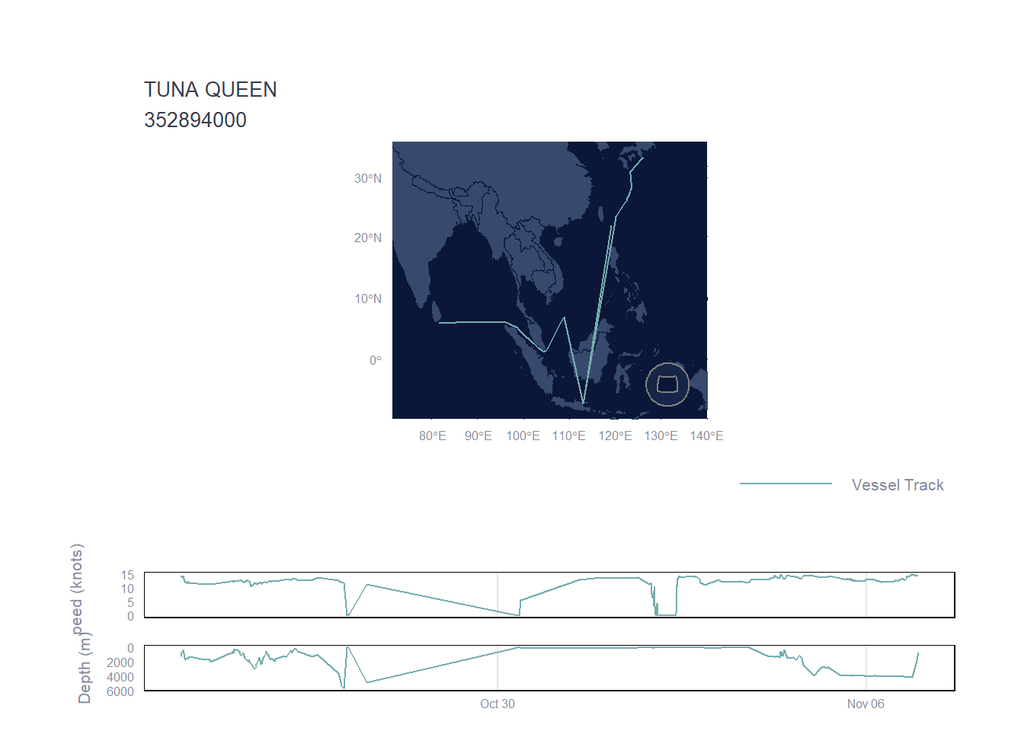

## 1.2 Wonky segments

**2. Based on what you are seeing, investigate the connection between, ssvid, vessel id, and seg_id during the time the track seems to make less sense using tables `pipe_production_v20201001.segment_info` and `world-fishing-827.gfw_research.pipe_v20201001_segs`. Can you identify what is occurring in the data to cause the wonky tracks?**

First, let’s check which parts of the tracks are problematic. The default fishwatchr fishing_track_review function does not have an option to overlay the points so we cannot see easily which segments are problematic. Plotting the points using ggplot() clearly shows the jump in AIS messages and the problematic segments.

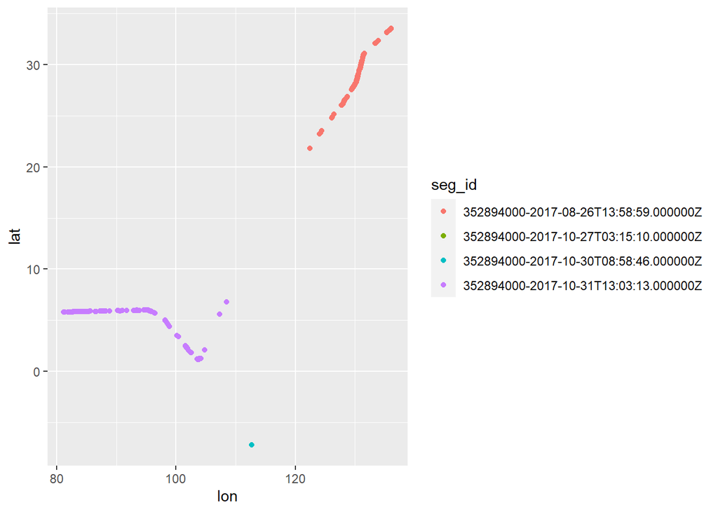

The track is composed of four unique seg_id (Table 1.1). We observe the following:

- *352894000-2017-08-26T13:58:59.000000Z* and *352894000-2017-10-31T13:03:13.000000Z* are the major segments with the most number of points
- *352894000-2017-10-27T03:15:10.000000Z* overlaps in time with the segment *352894000-2017-08-26T13:58:59.000000Z*
- *352894000-2017-10-30T08:58:46.000000Z* starts 2.8 days later than the preceding segment *352894000-2017-08-26T13:58:59.000000Z*

Table 1.1: Summary of segments in the track for MMSI 352894000

| seg_id | n_points | start_timestamp | end_timestamp |
| --- | --- | --- | --- |
| 352894000-2017-08-26T13:58:59.000000Z | 125 | 2017-10-24 00:01:13 | 2017-10-27 12:20:14 |
| 352894000-2017-10-27T03:15:10.000000Z | 4 | 2017-10-27 03:15:10 | 2017-10-27 04:15:56 |
| 352894000-2017-10-30T08:58:46.000000Z | 19 | 2017-10-30 08:58:46 | 2017-10-30 10:25:07 |
| 352894000-2017-10-31T13:03:13.000000Z | 295 | 2017-10-31 13:03:13 | 2017-11-06 23:26:29 |

Let’s pull out more information about the segments from the *pipe_production_v20201001.segment_info* table (Table 1.2). It looks like the same SSVID / MMSI corresponds to two different vessels (“TUNA QUEEN” and “ANELLY”) with different names, callsign, and imo.

```
## [1] "Running query..."
```

Table 1.2: Segment information derived from pipe_production_v20201001.segment_info table

| seg_id | ssvid | vessel_id | first_timestamp | last_timestamp | noise | shipname | callsign | imo | n_points |
| --- | --- | --- | --- | --- | --- | --- | --- | --- | --- |
| 352894000-2017-08-26T13:58:59.000000Z | 352894000 | 1512ca283-37b5-2737-87b9-047cf0f30433 | 2017-08-26 13:58:59 | 2017-10-27 12:20:14 | FALSE | TUNA QUEEN | HPFK | 9278612 | 125 |
| 352894000-2017-10-27T03:15:10.000000Z | 352894000 | 1512ca283-37b5-2737-87b9-047cf0f30433 | 2017-10-27 03:15:10 | 2017-10-27 04:15:56 | FALSE | ANELLY | VRYC3 | 0 | 4 |
| 352894000-2017-10-30T08:58:46.000000Z | 352894000 | 786d7faf6-65d3-6045-cfc8-3fd0ba9a9f58 | 2017-10-30 08:58:46 | 2017-10-30 10:25:07 | FALSE | ANELLY | VRYC3 | 0 | 19 |
| 352894000-2017-10-31T13:03:13.000000Z | 352894000 | 1512ca283-37b5-2737-87b9-047cf0f30433 | 2017-10-31 13:03:13 | 2017-11-23 20:20:03 | FALSE | TUNA QUEEN | HPFK | 9278612 | 295 |

## 1.3 Cleaned tracks

**3. Plot the track for MMSI 352894000 from October 24th 2017 - November 6 2017 again but removing noise.**

The noisy segments could be removed by filtering the *gfw_research.pipe_v20201001* with:

- good_seg IS TRUE
- overlapping_and_short IS FALSE from the *gfw_research.pipe_v20201001_segs* table.

The clean tracks for the vessel with MMSI 352894000 is shown below.

```
## [1] "Running query..."
```

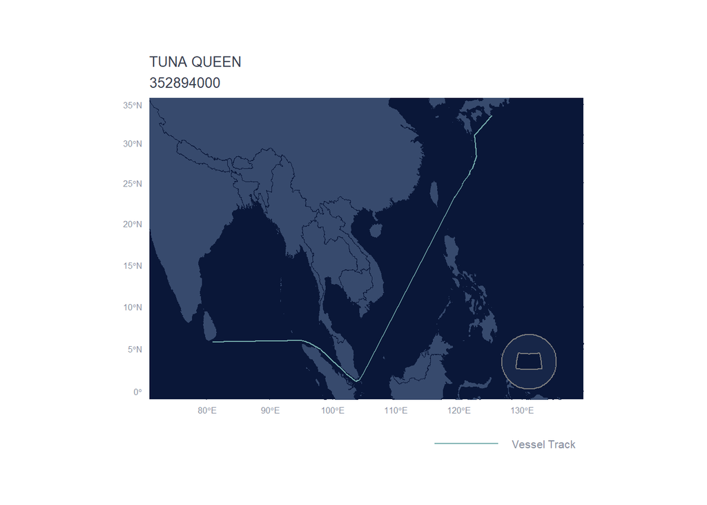

# 2 B. Vessel Info Questions

## 2.1 Vessel info query

**1. What is the name, callsign, flag state, and imo of the vessel with mmsi 353154000 during 2018?**

In 2018, the vessel with MMSI of 353154000 had different registry and AIS names (“KINGBEANS” vs. “CABO DE PALOS”), callsign (“3FKO6” vs. “HP5179”), and imo (“9550151” vs. “7363700”). Both the registry information and AIS indiate the same flag state: Panama.

```r
ssvid = '353154000'
year = 2018

query_vesselInfo<- glue::glue("
  SELECT
  ssvid AS mmsi,
  year AS year,
  registry_info.best_known_shipname AS registry_name,
  ais_identity.shipname_mostcommon.value AS ais_name,
  registry_info.best_known_callsign AS registry_callsign,
  ais_identity.n_callsign_mostcommon.value AS ais_callsign,
  registry_info.best_known_flag AS registry_flag,
  ais_identity.flag_mmsi AS ais_flag,
  registry_info.best_known_imo AS registry_imo,
  ais_identity.n_imo_mostcommon.value AS ais_imo,
  best.best_vessel_class AS vessel_class
  FROM `world-fishing-827.gfw_research.vi_ssvid_byyear_v20210706`
   WHERE
   ssvid = '{ssvid}'
   AND
   year = {year}
")


vesselInfo <- gfw_query(query = query_vesselInfo,
                          run_query = TRUE,
                          con = con)$data
```

```
## [1] "Running query..."
```

```r
vesselInfo %>%
  kable(caption = sprintf("Vessel information for %s for year %s",ssvid,year)) %>%
  kable_styling(bootstrap_options = c("striped", "hover", "condensed"),full_width = F,font_size=12)
```

(#tab:vesselInfo_Q1)Vessel information for 353154000 for year 2018

| mmsi | year | registry_name | ais_name | registry_callsign | ais_callsign | registry_flag | ais_flag | registry_imo | ais_imo | vessel_class |
| --- | --- | --- | --- | --- | --- | --- | --- | --- | --- | --- |
| 353154000 | 2018 | KINGBEANS | CABO DE PALOS | 3FKO6 | HP5179 | PAN | PAN | 9550151 | 7363700 | cargo |

## 2.2 Pulling from different tables

**2. Is the above answer different if you pull from the vessel info table (gfw_research.vi_ssvid_v) versus the vessel registry table (vessel_database.all_vessels_v)?**

*The two tables, “gfw_research.vi_ssvid_v” and “vessel_database.all_vessels_v”, does not have a “year” field.* *There are multiple returns for vessel_database.all_vessels_v versus the gfw_research.vi_ssvid_v query.*

```r
query_vesselInfo_vi <- glue::glue("
  SELECT
  ssvid AS mmsi,
  registry_info.best_known_shipname AS registry_name,
  ais_identity.shipname_mostcommon.value AS ais_name,
  registry_info.best_known_callsign AS registry_callsign,
  ais_identity.n_callsign_mostcommon.value AS ais_callsign,
  registry_info.best_known_flag AS registry_flag,
  ais_identity.flag_mmsi AS ais_flag,
  registry_info.best_known_imo AS registry_imo,
  ais_identity.n_imo_mostcommon.value AS ais_imo
  FROM `world-fishing-827.gfw_research.vi_ssvid_v20210706`
   WHERE
   ssvid = '{ssvid}'
")

vesselInfo_vi <- gfw_query(query = query_vesselInfo_vi,
                          run_query = TRUE,
                          con = con)$data
```

```
## [1] "Running query..."
```

```r
vesselInfo_vi %>%
  kable(caption = sprintf("Vessel information for %s for year %s from gfw_research.vi_ssvid_v20210706",ssvid,year)) %>%
  kable_styling(bootstrap_options = c("striped", "hover", "condensed"),full_width = F,font_size=12)
```

(#tab:vesselInfo_Q2a)Vessel information for 353154000 for year 2018 from gfw_research.vi_ssvid_v20210706

| mmsi | registry_name | ais_name | registry_callsign | ais_callsign | registry_flag | ais_flag | registry_imo | ais_imo |
| --- | --- | --- | --- | --- | --- | --- | --- | --- |
| 353154000 | KINGBEANS | KING BEANS | 3FKO6 | 3FKO6 | PAN | PAN | 9550151 | 9550151 |

```r
query_vesselInfo_allVessels <- glue::glue("
  SELECT
  identity.ssvid AS mmsi,
  identity.n_shipname AS name,
  identity.n_callsign AS callsign,
  identity.flag AS flag,
  identity.imo AS imo
  FROM `world-fishing-827.vessel_database.all_vessels_v20210601`
   WHERE
   identity.ssvid = '{ssvid}'
")

vesselInfo_allVessels <- gfw_query(query = query_vesselInfo_allVessels,
                          run_query = TRUE,
                          con = con)$data
```

```
## [1] "Running query..."
```

```r
vesselInfo_allVessels %>%
  kable(caption = sprintf("Vessel information for %s for year %s from vessel_database.all_vessels_v20210601",ssvid,year)) %>%
  kable_styling(bootstrap_options = c("striped", "hover", "condensed"),full_width = F,font_size=12)
```

(#tab:vesselInfo_Q2b)Vessel information for 353154000 for year 2018 from vessel_database.all_vessels_v20210601

| mmsi | name | callsign | flag | imo |
| --- | --- | --- | --- | --- |
| 353154000 | KINGBEANS | 3FKO6 | PAN | 9550151 |
| 353154000 | CABODEPALOS | HP5179 | PAN | 7363700 |
| 353154000 | EVEREST | HP5179 | PAN | 7363700 |
| 353154000 | CABODEPALOS | HP5179 | PAN | NA |

## 2.3 Using vi_ssvid_byyear_v

**3. Should you use gfw_research.vi_ssvid_v or gfw_research.vi_ssvid_byyear_v to answer question 1 in the vessel info section?**

*Since question 1 asks for the vessel identity for a specific year (i.e., 2018), the “gfw_research.vi_ssvid_byyear_v” table should be used. Vessel identity details could change over time and “gfw_research.vi_ssvid_v” contains the most common identity values.*

## 2.4 Carrier vessel?

**4. Is the vessel considered a ‘carrier’?**

No. Based on the table “gfw_research.vi_ssvid_byyear_v20210706”, the best vessel classification for the given mmsi is “cargo”.

## 2.5 Fishing vessel?

**5. Is the vessel a fishing vessel? What are different ways you could determine if the vessel was a fishing vessel?**

No. It is not a fishing vessel. The ways to determine if the vessel was a fishing vessel are:

- from vi_ssvid_byyear_vYYYYMMDD:
  - on_fishing_list_known - Listed as a fishing vessel on 1+ registries
  - on_fishing_list_sr - Consistently self reports as fishing in AIS messages >98% of messages; minimum 50 positions
  - on_fishing_list_nn - The neural net believes the vessel is more likely a fishing vessel than a non-fishing vessel combined neural net score for fishing classes > 0.5
  - on_fishing_list_best
- check if the ssvid is in the fishing_vessels_ssvid_vYYYYMMDD table

## 2.6 Vessel class

**6. What is considered based on the best vessel class? Does this differ from what it is considered when looking at vessel_database.all_vessels_v?**

*Best vessel class considers information from vessel registries, AIS activity, and inferred from the GFW neural net results. The vessel_database.all_vessels_v contains information only from vessel registries.*

## 2.7 RFMO authority

**7. Was the vessel ‘authorized’ by any RFMO during 2018? If so, which ones and what are the registry periods?**

*Yes. The vessel was authorized during 2018 by ICCAT.*

```r
query_regInfo <- glue::glue("
  SELECT
  identity.ssvid AS mmsi,
  identity.n_shipname AS name,
  identity.n_callsign AS callsign,
  identity.flag AS flag,
  identity.imo AS imo,
  registry.authorized_from,
  registry.authorized_to,
  registry.list_uvi,
  FROM `world-fishing-827.vessel_database.all_vessels_v20210601`,
    UNNEST(registry) AS registry
    WHERE
    identity.ssvid = '{ssvid}'
")

regInfo <- gfw_query(query = query_regInfo,
                          run_query = TRUE,
                          con = con)$data
```

```
## [1] "Running query..."
```

```r
datatable(regInfo, caption = sprintf("Registry information for %s for year %s from vessel_database.all_vessels_v20210601",ssvid,year))
```

|  | mmsi | name | callsign | flag | imo | authorized_from | authorized_to | list_uvi |
| --- | --- | --- | --- | --- | --- | --- | --- | --- |
| 1 | 353154000 | KINGBEANS | 3FKO6 | PAN | 9550151 |  |  | IMO-9550151/2010-02/2010-02 |
| 2 | 353154000 | KINGBEANS | 3FKO6 | PAN | 9550151 |  |  | IMO-9550151/2010-02/2010-02 |
| 3 | 353154000 | CABODEPALOS | HP5179 | PAN | 7363700 | 2021-03-28T00:00:00Z | 2022-03-28T00:00:00Z | ICCAT-AT000PAN00232 |
| 4 | 353154000 | CABODEPALOS | HP5179 | PAN | 7363700 | 2021-03-28T00:00:00Z | 2022-03-28T00:00:00Z | ICCAT-AT000PAN00232 |
| 5 | 353154000 | CABODEPALOS | HP5179 | PAN | 7363700 | 2021-03-28T00:00:00Z | 2022-03-28T00:00:00Z | ICCAT-AT000PAN00232 |
| 6 | 353154000 | CABODEPALOS | HP5179 | PAN | 7363700 | 2020-03-28T00:00:00Z | 2021-03-28T00:00:00Z | ICCAT-AT000PAN00232 |
| 7 | 353154000 | CABODEPALOS | HP5179 | PAN | 7363700 | 2020-03-28T00:00:00Z | 2021-03-28T00:00:00Z | ICCAT-AT000PAN00232 |
| 8 | 353154000 | CABODEPALOS | HP5179 | PAN | 7363700 | 2020-03-28T00:00:00Z | 2021-03-28T00:00:00Z | ICCAT-AT000PAN00232 |
| 9 | 353154000 | CABODEPALOS | HP5179 | PAN | 7363700 | 2020-03-28T00:00:00Z | 2021-03-28T00:00:00Z | ICCAT-AT000PAN00232 |
| 10 | 353154000 | CABODEPALOS | HP5179 | PAN | 7363700 | 2020-03-28T00:00:00Z | 2021-03-28T00:00:00Z | ICCAT-AT000PAN00232 |

[output cut: 163 more lines]

# 3 C. Fishing Inspection Questions

## 3.1 Fishing track and points plot

**1. We may also want to know about fishing. Plot a map of the track and fishing points by the vessel with the MMSI 367650000 between March 1 2017 and March 5 2017. Are there any issues with the track?**

There are tracks labelled as apparent fishing but looks like non-fishing (e.g., cruising / transiting) patterns.

```r
ssvid = '367650000'
dateRange <- c("2017-03-01","2017-03-05")

query_Tracks <- glue::glue(
  " SELECT
    ssvid,
    seg_id,
    lon,
    lat,
    hours,
    timestamp,
    nnet_score
    FROM
    `gfw_research.pipe_v20201001`
    WHERE seg_id IN (
      SELECT seg_id
      FROM `gfw_research.pipe_v20201001_segs`
      WHERE
      overlapping_and_short IS FALSE AND
      good_seg IS TRUE) AND
    ssvid = '{ssvid}' AND
    _partitiontime >= TIMESTAMP('{dateRange[1]}') AND
    _partitiontime <= TIMESTAMP('{dateRange[2]}') AND
    # Should we include nnet_scores that are NULL?
    nnet_score IS NOT NULL
    ORDER BY timestamp"
)

vTracks <- gfw_query(query = query_Tracks,
                          run_query = TRUE,
                          con = con)$data
```

```
## [1] "Running query..."
```

[output not shown]

[output cut: 1231 more lines]

[output not shown]

[output not shown]

[output cut: 16 more lines]

[output not shown]

[output not shown]

[output cut: 544 more lines]

[output not shown]

[output not shown]

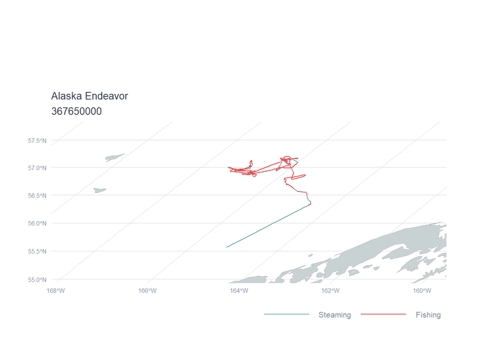

```
##
## $bbox
## $bbox$box_in
##       xmin       ymin       xmax       ymax
## -167.89678   55.06555 -164.03903   57.70273
##
## $bbox$box_out
##      xmin      ymin      xmax      ymax
## -12714949   6479510 -12120850   6721923
##
## $bbox$out_crs
## [1] "+proj=eqearth +datum=WGS84 +wktext"
```

```r
plot_vessel_track_fish(
  vTracks,
  bounding_box_man = NA,
  color_fishing = TRUE,
  color_by = "nnet_score",
  map_res = 10,
  theme = "light",
  buffer = 0.5,
  add_gridlines = TRUE,
  gfw_proj_name = "Equal Earth",
  vessel_name = "Alaska Endeavor" # name obtained by searching for the MMSI in the GFW map
)
```

```r
# # This is another way to plot the tracks
# land_sf <- rnaturalearth::ne_countries(scale = 10, returnclass = 'sf')
# plot_vessel_track(
#   vTracks,
#   lat = "lat",
#   lon = "lon",
#   show_fishing = TRUE,
#   spatial = TRUE
# )
```

**2. How many hours of fishing are estimated during this time? Is it different if you use the `pipe_production_v20201001.proto_events_fishing` table?**

```r
q_events <- glue::glue(
  " SELECT
    SUM(IF(event_type = 'fishing',
     TIMESTAMP_DIFF(event_end, event_start, MINUTE),
     0))/60 AS fishing_hours
    FROM
    `pipe_production_v20201001.proto_events_fishing`
    WHERE
    event_start BETWEEN TIMESTAMP('{dateRange[1]}') AND TIMESTAMP('{dateRange[2]}')
    AND
    seg_id LIKE '{ssvid}-%'
    "
)

events_hours <- gfw_query(query = q_events,
                          run_query = TRUE,
                          con = con)$data
```

```
## [1] "Running query..."
```

The total fishing hours is 98.87 out of 109.7158333 total voyage hours using the *‘gfw_research.pipe_v20201001_fishing’* table.

The total fishing hours using the *‘pipe_production_v20201001.proto_events_fishing’* is 74.1333333.

**3. What type of fishing vessel is it?**

**4. Provide the other vessel identity information and registry records during this time.**

```r
ssvid = '353154000'
year = 2018

query_vesselInfo<- glue::glue("
  SELECT
    ssvid,
    lon,
    lat,
    timestamp,
    speed_knots,
    -1 * elevation_m AS depth_m,
    distance_from_shore_m/1000 AS distance_from_shore_km,
    nnet_score
    FROM
    `gfw_research.pipe_v20201001`
    WHERE seg_id IN (
    SELECT seg_id
    FROM `gfw_research.pipe_v20201001_segs`
    WHERE
    overlapping_and_short IS FALSE AND
    good_seg IS TRUE) AND
    ssvid = '{ssvid}' AND
    _partitiontime BETWEEN TIMESTAMP('{dateRange[1]}') AND TIMESTAMP('{dateRange[2]}') AND
    nnet_score IS NOT NULL
    ORDER BY timestamp
")


vesselInfo <- gfw_query(query = query_vesselInfo,
                          run_query = TRUE,
                          con = con)$data
```

```
## [1] "Running query..."
```

```r
vesselInfo %>%
  kable(caption = sprintf("Vessel information for %s for year %s",ssvid,year)) %>%
  kable_styling(bootstrap_options = c("striped", "hover", "condensed"),full_width = F,font_size=12)
```

| ssvid | lon | lat | timestamp | speed_knots | depth_m | distance_from_shore_km | nnet_score |
| --- | --- | --- | --- | --- | --- | --- | --- |
| 353154000 | 35.44632 | -25.374550 | 2017-03-01 00:00:12 | 11.6 | 1077 | 91 | 0 |
| 353154000 | 35.44808 | -25.372217 | 2017-03-01 00:01:03 | 11.7 | 1077 | 91 | 0 |
| 353154000 | 35.46248 | -25.353267 | 2017-03-01 00:07:45 | 11.8 | 1082 | 89 | 0 |
| 353154000 | 35.46752 | -25.346533 | 2017-03-01 00:10:15 | 11.8 | 1124 | 90 | 0 |
| 353154000 | 35.47310 | -25.339350 | 2017-03-01 00:13:13 | 11.9 | 1100 | 89 | 0 |
| 353154000 | 35.50398 | -25.298433 | 2017-03-01 00:28:12 | 11.9 | 1144 | 86 | 0 |
| 353154000 | 35.50710 | -25.294283 | 2017-03-01 00:29:43 | 11.8 | 1173 | 86 | 0 |
| 353154000 | 35.51478 | -25.283817 | 2017-03-01 00:33:33 | 11.8 | 1156 | 85 | 0 |
| 353154000 | 35.51800 | -25.279667 | 2017-03-01 00:35:04 | 11.9 | 1202 | 85 | 0 |
| 353154000 | 35.52858 | -25.265650 | 2017-03-01 00:40:13 | 11.8 | 1227 | 85 | 0 |
| 353154000 | 35.56155 | -25.222583 | 2017-03-01 00:56:03 | 11.8 | 1129 | 82 | 0 |
| 353154000 | 35.57007 | -25.211450 | 2017-03-01 01:00:13 | 11.7 | 1092 | 82 | 0 |
| 353154000 | 35.57525 | -25.204567 | 2017-03-01 01:02:42 | 11.8 | 1059 | 81 | 0 |
| 353154000 | 35.58092 | -25.197350 | 2017-03-01 01:05:24 | 11.8 | 1059 | 81 | 0 |
| 353154000 | 35.59345 | -25.181267 | 2017-03-01 01:11:24 | 11.7 | 1012 | 80 | 0 |
| 353154000 | 35.61363 | -25.154933 | 2017-03-01 01:21:12 | 11.7 | 1018 | 79 | 0 |
| 353154000 | 35.62433 | -25.141000 | 2017-03-01 01:26:23 | 11.6 | 1047 | 79 | 0 |
| 353154000 | 35.63480 | -25.127333 | 2017-03-01 01:31:34 | 11.6 | 1073 | 79 | 0 |
| 353154000 | 35.63587 | -25.125900 | 2017-03-01 01:32:03 | 11.7 | 1120 | 79 | 0 |
| 353154000 | 35.63813 | -25.122850 | 2017-03-01 01:33:13 | 11.6 | 1093 | 79 | 0 |
| 353154000 | 35.64022 | -25.120217 | 2017-03-01 01:34:13 | 11.5 | 1093 | 79 | 0 |
| 353154000 | 35.64402 | -25.115267 | 2017-03-01 01:36:03 | 11.5 | 1093 | 79 | 0 |
| 353154000 | 35.64628 | -25.112217 | 2017-03-01 01:37:14 | 11.6 | 1104 | 79 | 0 |
| 353154000 | 35.65305 | -25.103383 | 2017-03-01 01:40:31 | 11.5 | 1075 | 78 | 0 |
| 353154000 | 35.68027 | -25.067667 | 2017-03-01 01:54:03 | 11.4 | 1082 | 77 | 0 |
| 353154000 | 35.69137 | -25.052717 | 2017-03-01 01:59:44 | 11.4 | 1076 | 77 | 0 |
| 353154000 | 35.71052 | -25.027600 | 2017-03-01 02:09:22 | 11.3 | 1151 | 76 | 0 |
| 353154000 | 35.72193 | -25.013017 | 2017-03-01 02:15:03 | 11.1 | 1208 | 76 | 0 |
| 353154000 | 35.73245 | -24.999967 | 2017-03-01 02:20:12 | 11.4 | 1244 | 76 | 0 |
| 353154000 | 35.73775 | -24.993450 | 2017-03-01 02:22:42 | 11.5 | 1263 | 76 | 0 |

[output cut: 1075 more lines]